# Thera_Bank Project_Final

## Bagging Models

### Decision Tree Model

- We will build our model using the DecisionTreeClassifier function. Using default 'gini' criteria to split.
- If the frequency of class A is 10% and the frequency of class B is 90%, then class B will become the dominant class and the decision tree will become biased toward the dominant classes.
- In this case, we can pass a dictionary {0:0.16,1:0.84} to the model to specify the weight of each class and the decision tree will give more weightage to class 1.
- class_weight is a hyperparameter for the decision tree classifier.

```python
dtr = DecisionTreeClassifier(criterion='gini',class_weight={0:0.16,1:0.84},random_state=1)
```

```python
dtr.fit(X_train, y_train)
```

```
DecisionTreeClassifier(class_weight={0: 0.16, 1: 0.84}, random_state=1)
```

```
Accuracy on training set :  1.0
Accuracy on test set :  0.935176044751563
Recall on training set :  1.0
Recall on test set :  0.8114754098360656
Precision on training set :  1.0
Precision on test set :  0.7904191616766467
```

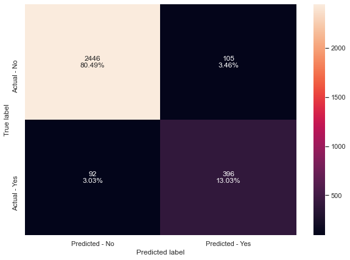

```python
#Calculating different metrics
scores_dtr = get_metrics_score(dtr,X_train,X_test,y_train,y_test)

# creating confusion matrix
make_confusion_matrix(dtr,y_test)
```

- Decision tree is working well on the training data but is not able to generalize well on the test data concerning the recall.There is overfitting

**Confusion Matrix -**

- Customer attrited and the model predicted it correctly that customer will attrite : True Positive (observed=1,predicted=1)
- Customer didn't attrite and the model predicted customer will attrite : False Positive (observed=0,predicted=1)
- Customer didn't attrite and the model predicted customer will not attrite : True Negative (observed=0,predicted=0)
- Customer attrited and the model predicted that customer won't : False Negative (observed=1,predicted=0)

### Bagging Classifier

```python
bagged = BaggingClassifier(random_state=1)
bagged.fit(X_train,y_train)
```

```
BaggingClassifier(random_state=1)
```

```
Accuracy on training set :  0.9968961625282167
Accuracy on test set :  0.9585389930898321
Recall on training set :  0.9833187006145742
Recall on test set :  0.8422131147540983
Precision on training set :  0.9973285841495992
Precision on test set :  0.8934782608695652
```

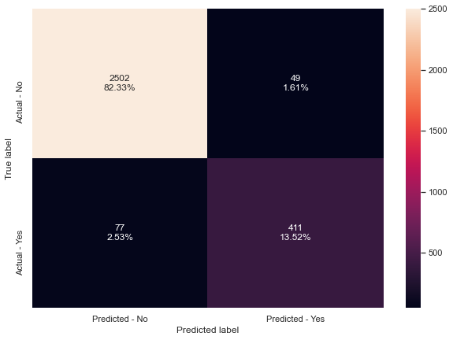

```python
#Calculating different metrics
scores_bagged = get_metrics_score(bagged,X_train,X_test,y_train,y_test)

# creating confusion matrix
make_confusion_matrix(bagged,y_test)
```

- Bagging classifier is generalizing well on the training set and fairly okay on the test set in terms of recall. This is better than the Decision Tree Model. This is a good model though with some overfitting

#### Confusion Matrix

- The number of True Positives has increased and the False Positives which would have cost the bank a lot if misclassified has greatly reduced.

### Bagging Classifier with weighted decision tree

```python
bagged_wt = BaggingClassifier(base_estimator=DecisionTreeClassifier(criterion='gini',class_weight={0:0.16,1:0.84},random_state=1),random_state=1)
bagged_wt.fit(X_train,y_train)
```

```
BaggingClassifier(base_estimator=DecisionTreeClassifier(class_weight={0: 0.16,
                                                                      1: 0.84},
                                                        random_state=1),
                  random_state=1)
```

```
Accuracy on training set :  0.996331828442438
Accuracy on test set :  0.9545903257650543
Recall on training set :  0.9815627743634767
Recall on test set :  0.8237704918032787
Precision on training set :  0.9955476402493322
Precision on test set :  0.8854625550660793
```

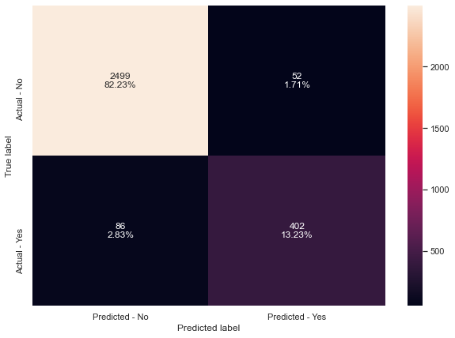

```python
#Calculating different metrics
scores_bagged_wt = get_metrics_score(bagged_wt,X_train,X_test,y_train,y_test)

# creating confusion matrix
make_confusion_matrix(bagged_wt,y_test)
```

- Bagging classifier with a weighted decision tree is giving very good accuracy and precision but is not able to generalize well on test data in terms of recall.

### Random Forest

```python
rf = RandomForestClassifier(random_state=1)
rf.fit(X_train,y_train)
```

```
RandomForestClassifier(random_state=1)
```

```
Accuracy on training set :  1.0
Accuracy on test set :  0.9519578808818691
Recall on training set :  1.0
Recall on test set :  0.7622950819672131
Precision on training set :  1.0
Precision on test set :  0.9253731343283582
```

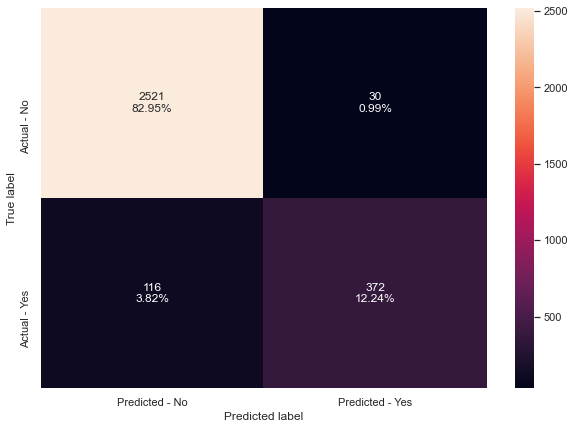

```python
#Calculating different metrics
scores_rf = get_metrics_score(rf,X_train,X_test,y_train,y_test)

# creating confusion matrix
make_confusion_matrix(rf,y_test)
```

- Random Forest model is overfitted, and is not equally able to generalize well on the test data in terms of recall. Overfitting model

**Random forest with class weights**

```python
rf_wt = RandomForestClassifier(class_weight={0:0.16,1:0.84}, random_state=1)
rf_wt.fit(X_train,y_train)
```

```
RandomForestClassifier(class_weight={0: 0.16, 1: 0.84}, random_state=1)
```

```
Accuracy on training set :  1.0
Accuracy on test set :  0.9506416584402764
Recall on training set :  1.0
Recall on test set :  0.7459016393442623
Precision on training set :  1.0
Precision on test set :  0.9333333333333333
```

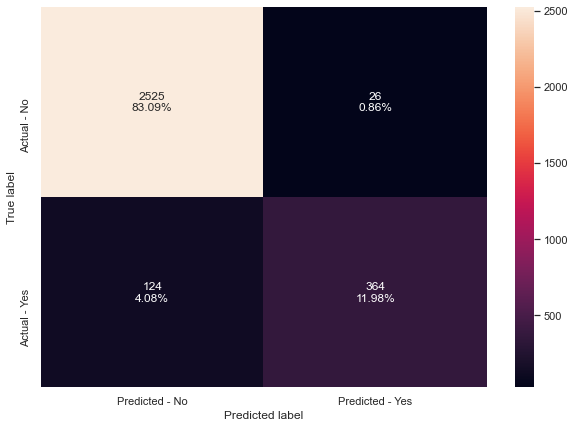

```python
#Calculating different metrics
scores_rf_wt = get_metrics_score(rf_wt,X_train,X_test,y_train,y_test)

# creating confusion matrix
make_confusion_matrix(rf_wt,y_test)
```

- The Training Set is Overfitting with quite a low Recall on Test.
- There is not much improvement in metrics of weighted random forest as compared to the unweighted random forest.

#### Bagging Classifier turns out to be the Best Bagging Model and will be tuned